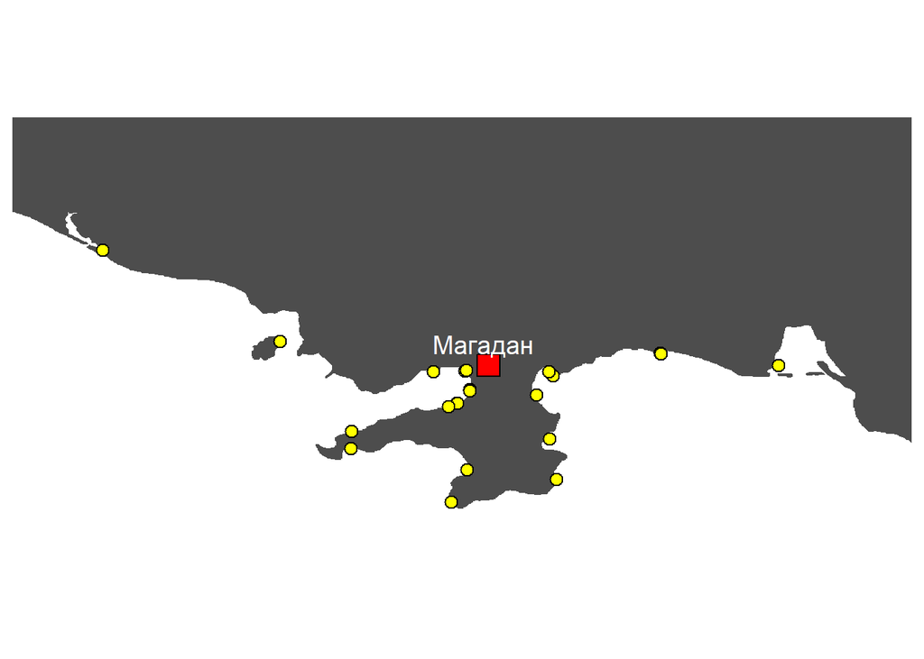

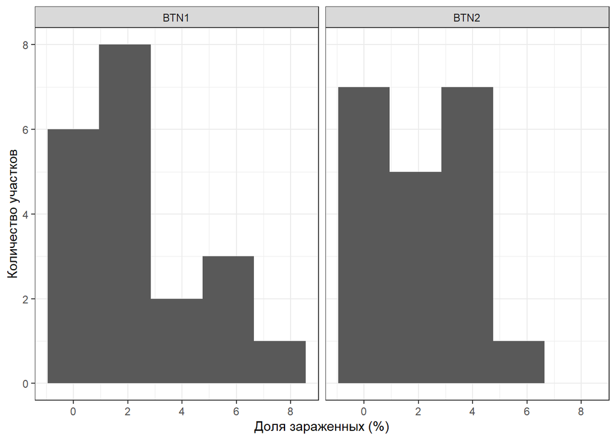

Частота зараженных мидий невелика: единицы процентов в поселении

[figure not shown]

Частота BTN варьирует вдоль побережья

## Размерная структура и обилие мидий

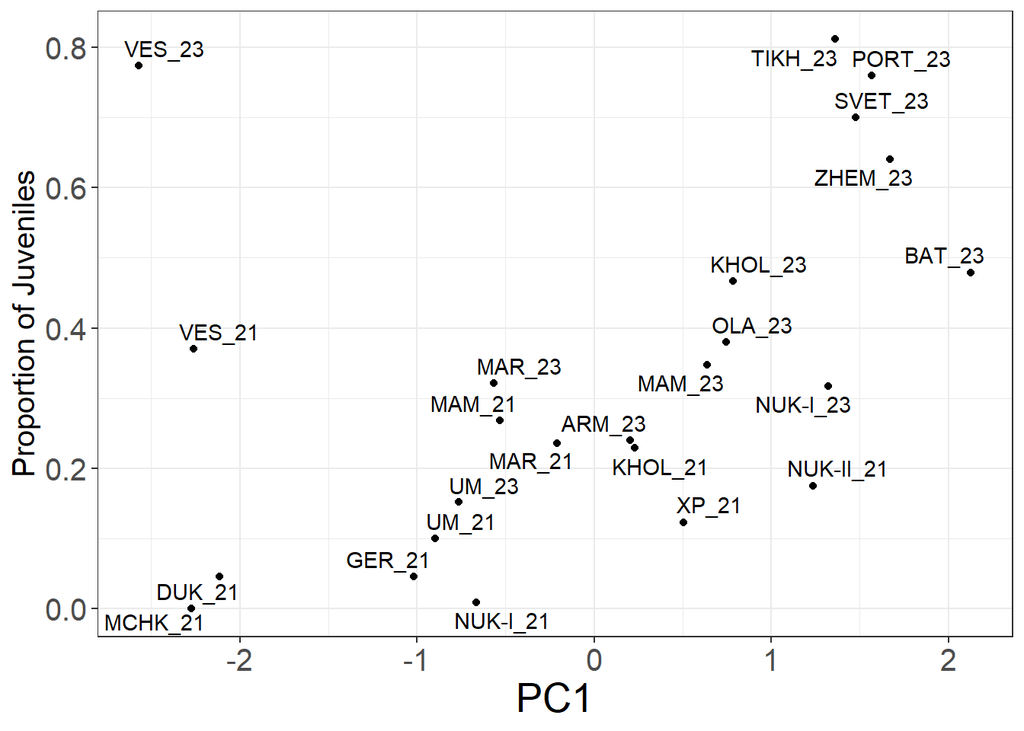

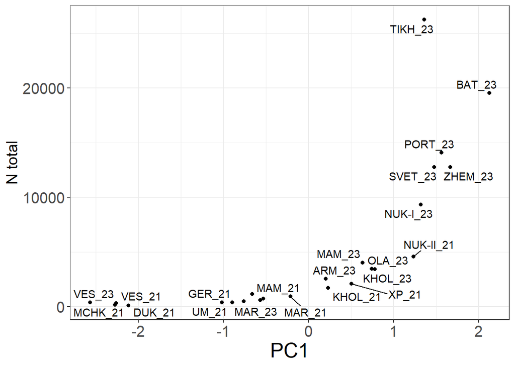

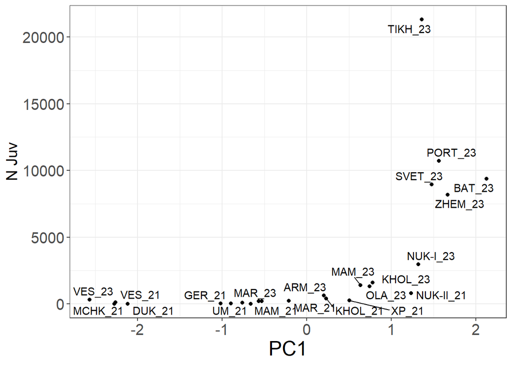

Внимание! В данном варианте анализа исходная матрица для PCA - это плотности поселения мидий разных размерных классов умноженные на проективное покрытие (для нескольких сайтов 2021 г это покрытие оценено грубо по визуальному сравнению с сайтами, где оно оценено точно). Полученные значения еще и логарифмированы.

PC1 - это плотность поселения и доминирование молоди. НО! Если посмотреть на размерную структуру, то можно увидеть следующее

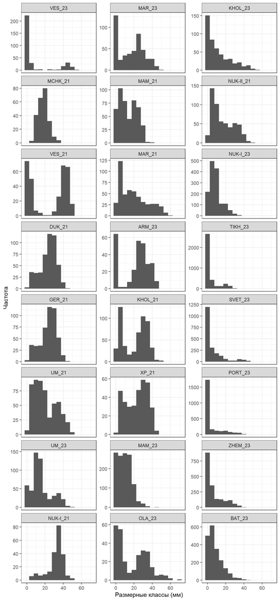

Здесь сайты упорядочены по мере увеличения значения PC1 (вниз по каждой колонке). Создается впечатление, что самые низкие значения PC1 - это доминирование стариков. Самые высокие значения PC1 - Это доминирование молоди.

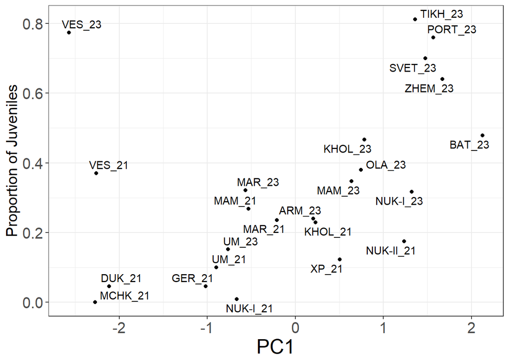

Не спеши, как всегда, говорить, что все хуйня. Подумай. Тут что-то есть, в особенности если смотреть на связь с зараженностью BTN1 (см. ниже).

Кроме того, обрати внимание, что большинство (хотя и не все) сборов 2023 лежат в правой части градиента PC1. Отсюда и разночтения в предсказаниях модели, построенной на данных 2023 г. То есть мы смоделировали, используя только данные 2023 г., связь только с частью градиента плотности-структуры (или динамики).

# Связь зараженности со средовыми предикторами

### Проверка валидности модели

```
## Object of Class DHARMa with simulated residuals based on 250 simulations with refit = FALSE . See ?DHARMa::simulateResiduals for help.
##
## Scaled residual values: 0.1676057 0.30146 0.5211004 0.6230243 0.1944108 0.6692155 0.7653073 0.6651239 0.3275799 0.7117218 0.3887831 0.1855208 0.2626375 0.2564023 0.7126933 0.9004533 0.03300054 0.8770003 0.04193034 1 ...
```

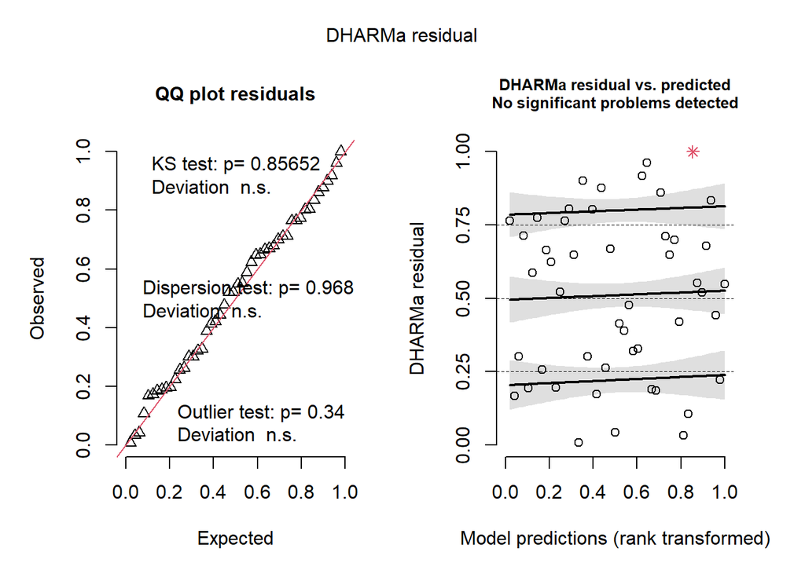

Все чисто, вроде.

### Результат построения модели

```
##
## Family: binomial
## Link function: logit
##
## Formula:
## cbind(N_cancer, N_helthy) ~ s((Dist_Port), by = Lineage, bs = "cr",
##     k = 10) + s((fetch), by = Lineage, bs = "cr", k = 10) + s((PC1),
##     by = Lineage, bs = "cr", k = 10) + s((OGP), by = Lineage,
##     bs = "cr", k = 10) + Lineage + Year + s(Site, bs = "re")
##
## Parametric coefficients:
##               Estimate Std. Error z value Pr(>|z|)
## (Intercept) -4.334e+00  2.966e-01 -14.613   <2e-16 ***
## LineageBTN2  5.091e-02  2.784e-01   0.183    0.855
## Year2023     3.616e-05  2.416e-01   0.000    1.000
## ---
## Signif. codes:  0 '***' 0.001 '**' 0.01 '*' 0.05 '.' 0.1 ' ' 1
##
## Approximate significance of smooth terms:
##                            edf Ref.df Chi.sq  p-value
## s(Dist_Port):LineageBTN1 1.000  1.000  3.884 0.048749 *
## s(Dist_Port):LineageBTN2 1.000  1.000  0.647 0.421203
## s(fetch):LineageBTN1     1.000  1.000  9.644 0.001900 **
## s(fetch):LineageBTN2     1.000  1.000  1.184 0.276539
## s(PC1):LineageBTN1       1.000  1.000  5.109 0.023802 *
## s(PC1):LineageBTN2       1.567  1.905  3.819 0.203735
## s(OGP):LineageBTN1       1.000  1.000  6.747 0.009392 **
## s(OGP):LineageBTN2       1.112  1.197  8.208 0.006206 **
## s(Site)                  6.824 16.000 36.274 0.000172 ***
## ---
## Signif. codes:  0 '***' 0.001 '**' 0.01 '*' 0.05 '.' 0.1 ' ' 1
##
## R-sq.(adj) =  0.465   Deviance explained = 68.4%
## -REML = 75.414  Scale est. = 1         n = 48
```

Здесь нашел небольшую багу в модели (лучше исполльзовать basic spline не “thin plate”, как было, a “cubic regression”). После объединения данных 2021 и 2023 гг OGP значимо влияет на частоту обеих форм BTN

### Визуализация модели

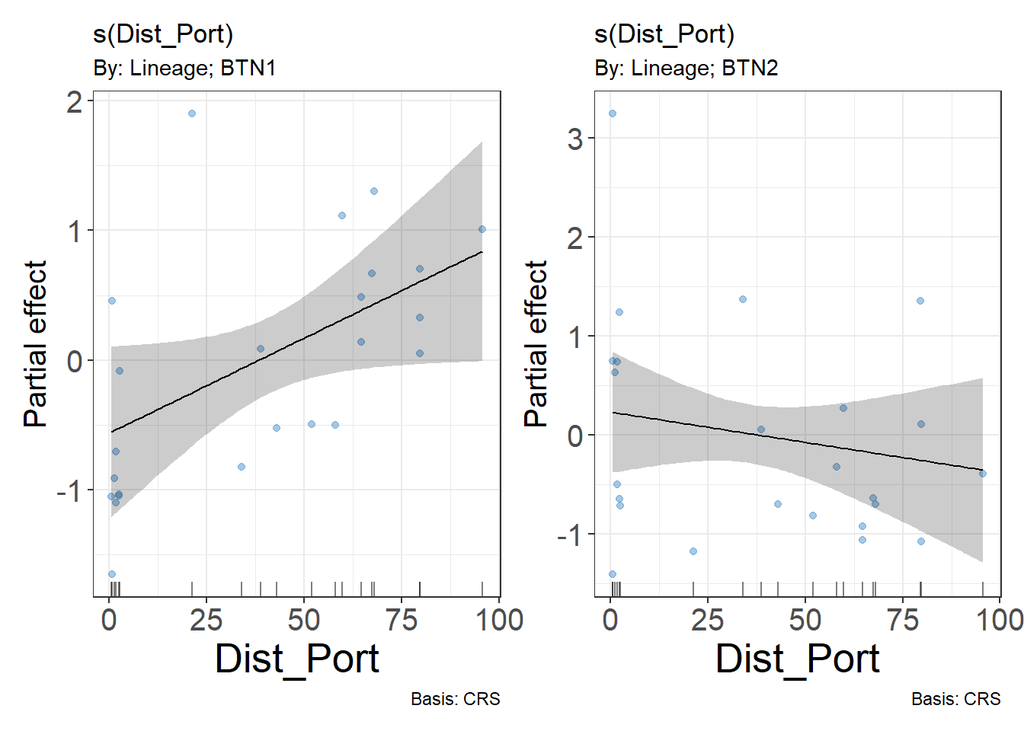

Здесь все как было!

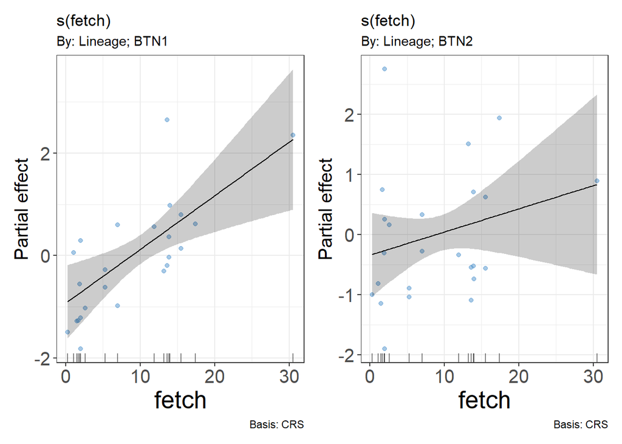

Здесь все как было!

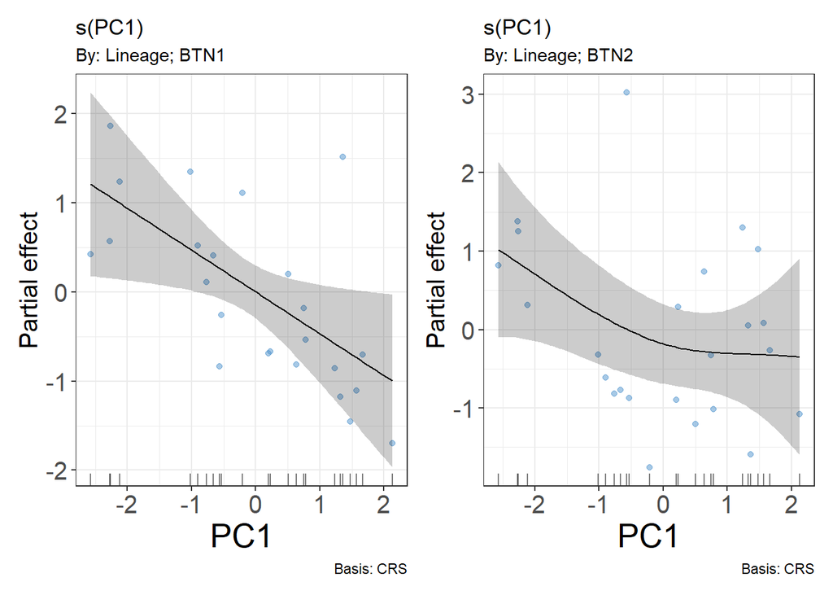

At! Здесь, после объединения 2021 и 2023 гг результаты изменились. Получается, что при более высоких значениях PC1 зараженность ниже. То есть, BTN1 встречается чаще там, где много стариков (этого не было видно, когда модель строили только на данных 2023 г.).

Так вот, если это PC1 - это циклическая динамика, то все может быть совсем здорово. BTN1 имеет максимум частоты в тех поселениях, где живут старые, уже ослабленные старики. Возможно он их добивает. BTN2, будучи более специализированным и коадаптированным с хозяином паразитом, использует ресурс (хозяина) на всех стадиях его популяционной динамики.

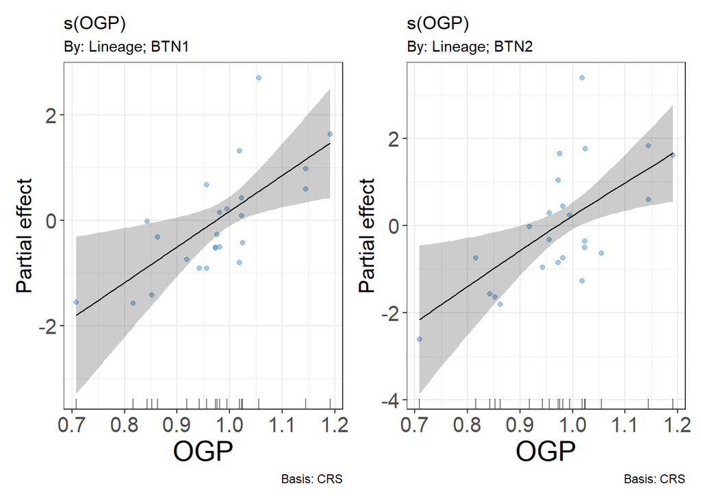

Здесь вылезла положительная связь с OGP у обеих BTN. Формально это означает, что если “убрано” (учтено) влияние прочих предикторов, то при прочих равных обе линии себя лучше чувствуют в поселениях, где мидии лучше идет рост. “В здоровом теле здоровый паразит”? Это, возможно, мэтчится с нелюбовью близости к порту, так как антропогенное влияние должно как-то подавлять рост. Да и вообще, если рост - это интегральный показатель фитнеса, то эта связь говорит о том, что BTN не развивается как следствие жизни в неблагоприятных условиях.

# Влияние BTN на хозяина

## Зависимость частоты нарушения развития гонад от степени развития заболевания

Параметры GAM

| Член модели | edf | ref.df | Chi.sq Statistic | p.value |
| --- | --- | --- | --- | --- |
| s(Aneuploid_Proportion):LineageBTN1 | 1.0 | 1.0 | 12.5 | 0.000 |
| s(Aneuploid_Proportion):LineageBTN2 | 1.0 | 1.0 | 7.1 | 0.008 |

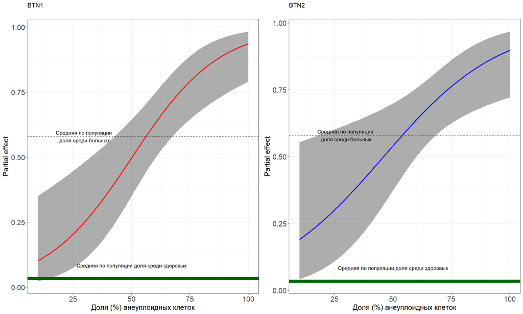

При заражении MtrBTN1 видимые нарушения наступают на более поздних стадиях заболевания, при заражении MtrBTN2 видимые нарушения наступают раньше, уже начиная с ранних стадий заболевания

## Влияние BTN на рост моллюсков

| Член модели | estimate | std.error | F | p.value |
| --- | --- | --- | --- | --- |
| (Intercept) | 25.87 | 1.08 | 23.92 | 0.0000 |
| BTN_TypeBTN2 | 4.35 | 1.42 | 3.06 | 0.0022 |
| BTN_TypeЗдоровые | -0.79 | 0.94 | -0.84 | 0.4027 |

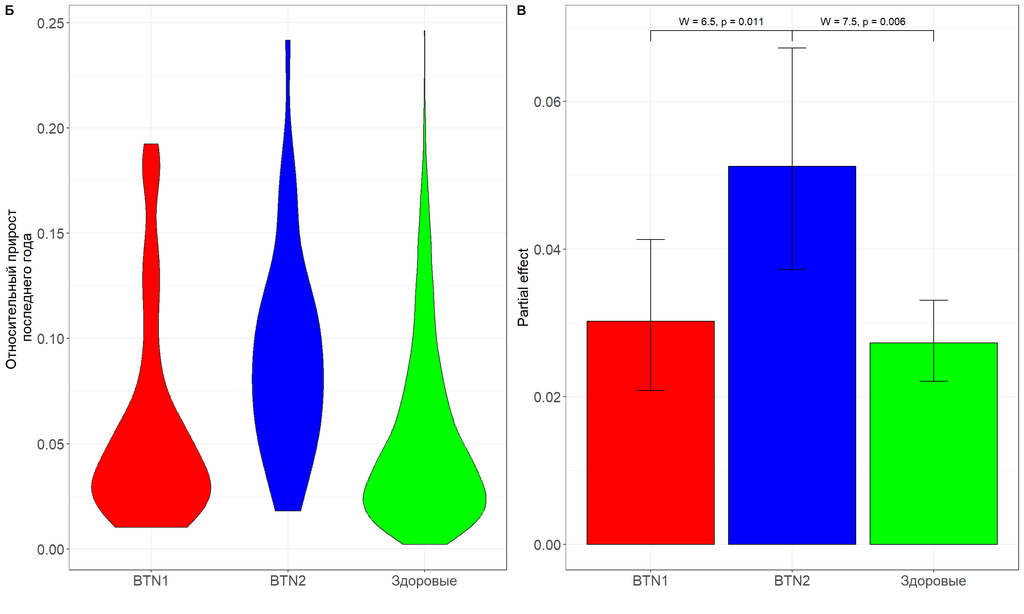

## Зависимость прироста от доли анеуплоидных клеток

```
##
## Family: gaussian
## Link function: identity
##
## Formula:
## Fi_Increment ~ s(Aneuploid_Proportion, by = Lineage, bs = "cr") +
##     s(Last_ring, by = Lineage) + Lineage
##
## Parametric coefficients:
##             Estimate Std. Error t value Pr(>|t|)
## (Intercept)   27.913      1.286  21.704  < 2e-16 ***
## LineageBTN2    4.747      1.777   2.672  0.00934 **
## ---
## Signif. codes:  0 '***' 0.001 '**' 0.01 '*' 0.05 '.' 0.1 ' ' 1
##
## Approximate significance of smooth terms:
##                                       edf Ref.df      F  p-value
## s(Aneuploid_Proportion):LineageBTN1 1.605  1.958  2.002    0.183
## s(Aneuploid_Proportion):LineageBTN2 1.000  1.001  0.077    0.783
## s(Last_ring):LineageBTN1            2.518  3.148 11.747 2.29e-06 ***
## s(Last_ring):LineageBTN2            2.359  2.947 10.032 2.27e-05 ***
## ---
## Signif. codes:  0 '***' 0.001 '**' 0.01 '*' 0.05 '.' 0.1 ' ' 1
##
## R-sq.(adj) =  0.522   Deviance explained = 57.3%
## -REML = 269.86  Scale est. = 57.577    n = 81
```

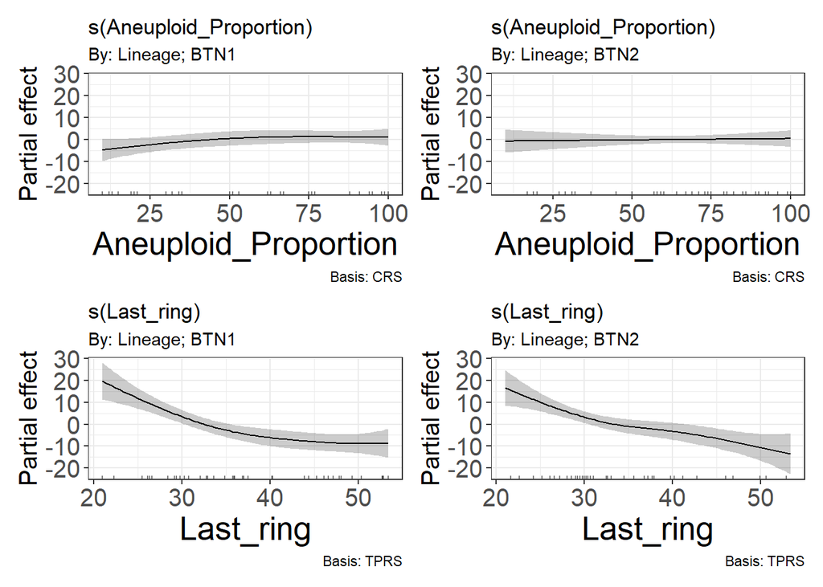

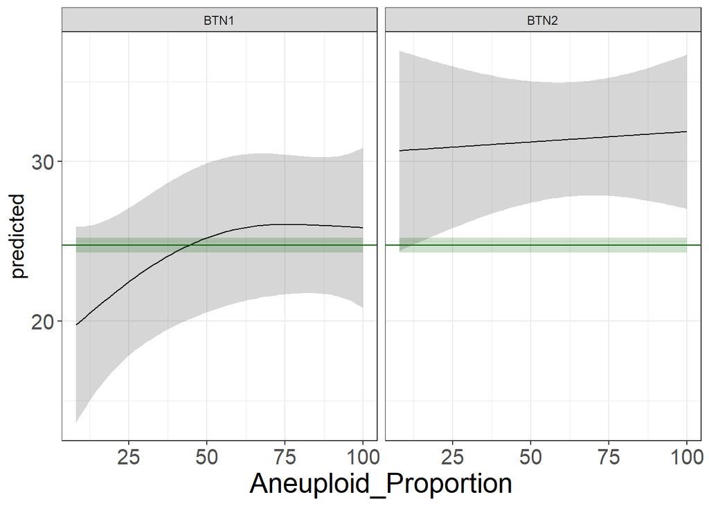